# R Notebook

# Loading in libraries

```r
library(tidyverse)
library(scales)
library(CodeClanData)
```

# 1. Looking at variable names and dimensions of backpack data set

```r
dim(backpack)
```

```
[1] 100   9
```

```r
names(backpack)
```

```
[1] "backpack_weight" "body_weight"     "ratio"           "back_problems"   "major"           "year"
[7] "sex"             "status"          "units"
```

```r
view(backpack)
```

Backpack variable names :

[1] “backpack_weight” “body_weight” “ratio” “back_problems” “major” “year”  
[7] “sex” “status” “units”

# 2. Graph showing distribution of backpack weights that students are carrying

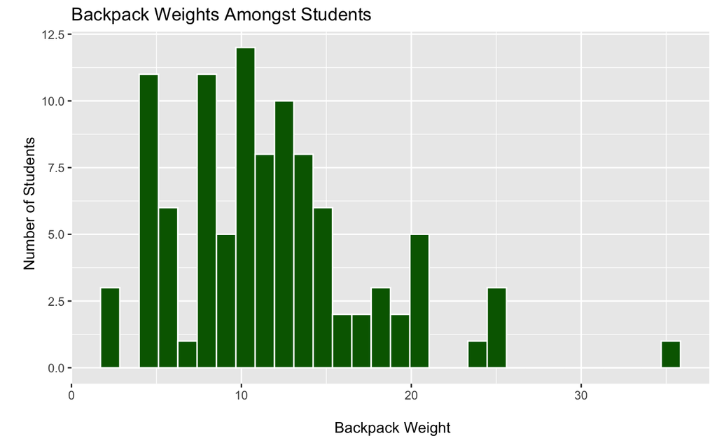

```r
ggplot(backpack) +
  geom_histogram(aes(x = backpack_weight), col = "white", fill = "dark green") +
  labs(x = "\n Backpack Weight",
       y = "\n  Number of Students",
       title = "Backpack Weights Amongst Students")
```

The distribution of backpack weights amongst students can be said to be skewed to the right (positively skewed). More students carry backpacks with smaller weight values than those with larger weight values.

# 3. Graph depicting distribution of backpack weights that students are carrying by sex

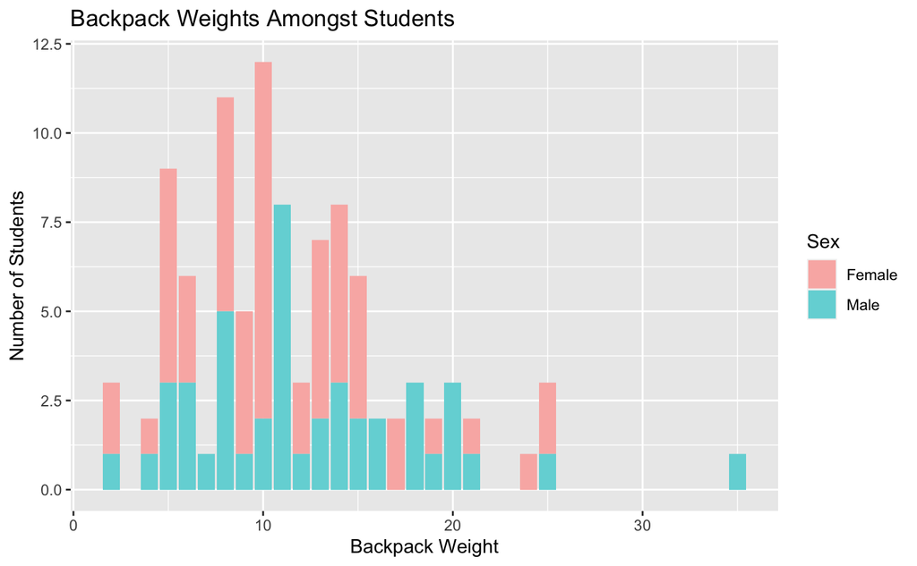

```r
ggplot(backpack) +
  geom_bar(aes(x = backpack_weight, fill = sex)) +
  labs(
    x = "Backpack Weight",
    y = "Number of Students",
    title = "Backpack Weights Amongst Students",
    fill = "Sex"
  ) + scale_fill_hue(c=45, l=80)
```

```r
NA
```

This bar graph shows the different backpack weights that students carry but also how these are distributed amongst female and male students.